# Estimate Ideologies in a Social Network

Shichao Ma

November 12, 2018

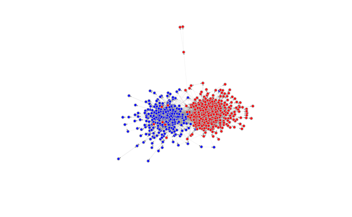

# Introduction

Social networks contain invaluable information regarding actors in the network. Given actors’ social connections and plausible motivations behind the establishment of these relations, one may infer actors’ unobserved characteristics, which are of interest by themselves or can have further use.

In this project, I develop a new method to estimate actors’ socioeconomic ideologies using network data. The social network considered in this paper can be represented by a directed graph that contains binary relations directed from one actor to another (e.g, following or citation). Actors in the social network establish connections because of their ideological similarity.

# The Model

For the ease of demonstration, a social network is represented by an $n \times n$ sociomatrix $Y$. Here I only consider binary relations, i.e., either a connection is absent or exist, and use 0 and 1 to denote them. Therefore, a typical element in a sociomatrix is
$$y_{ij}=\begin{cases}
1 & \quad \text{if i follows j}\\
0 & \quad \text{otherwise}
\end{cases}$$
By convention, selfrelation is dismissed: $y_{ii} = 0$ for all $i$.

I assume (part of) the reason for an individual to establish her connections is she shares a similar view on socioeconomic issues with her followers and followees. Such a view can be summarized by their ideologies, which lie in a one-dimensional ideological space (e.g., liberal vs. conservative) and can be represented by the real line $\mathrm{R}$. Mathematically, I assume a generic actor $i$ has an ideal position $\theta_i \in \mathrm{R}$. The act of following another actor $j$ will bring her $-(\theta_i - \theta_j)^2 + b_i$ utility.

However, establishing a connection is not free, as people have limited time and energy to manage their relations. Thus, I assume actor $i$ needs to pay $c_i$ to establish a relation. Therefore, establishing a relation with $j$ will bring $-(\theta_i - \theta_j)^2 - c_i + b_i$ in total for actor $i$. For a given set of possible relations, actor $i$’s choice is
$$\max_{y_{ij}\in\{0,1\}} \sum_{j \neq i} -y_{ij}(\theta_i - \theta_j)^2 - y_{ij}(c_i - b_i).$$

# Estimation

## Logistic Representation and the Log-likelihood

A simple and natural way to specify the probability of establishing a relation from $i$ to $j$ is applying the logistic model:
$$\Pr(y_{ij}=1|\theta_{i},\theta_{j},b_{i},c_{i})=\text{logit}^{-1}(-(\theta_{i}-\theta_{j})^{2}-c_{i}+b_{i}) = \text{logit}^{-1}(-(\theta_{i}-\theta_{j})^{2}-C_{i})$$
Because we have two linear terms for a given individual ($b_i$ and $c_i$), they cannot be identified separately (they are collinear). So I use $C_i \equiv c_i - b_i$ to replace the difference of them. After this substitution, the log-likelihood function is straightforward:
$$\log\mathcal{L}(Y|\theta,C)=\sum_{i}\sum_{j\neq i}\left\{ -y_{ij}\log\left(1+\exp((\theta_{i}-\theta_{j})^{2}+C_{i}\right)-(1-y_{ij})\log\left(1+\exp(-(\theta_{i}-\theta_{j})^{2}-C_{i}\right)\right\}$$
Our job is to estimate $\theta_i$ and $C_i$ for all $i$’s using the relations presented in a social network. The model in total has $2n$ parameters with $n(n-1)$ observations ($n$ is the number of individuals). To speed up the convergence, the model is estimated by a two-stage iterative maximum likelihood algorithm. The first stage estimates $C_i$ while holding $\theta_i$’s constant. The second stage estimates $\theta_i$while fixing $C_i$’s.

## Data

I study a network data of online political blogs collected by Adamic and Glance (2005). This data is publicly available from http://nexus.igraph.org/. It contains blogroll links and post citations of 1490 political blogs before the US Presidential Election of 2004. In our term, a blog establishes a connection with another blog if it cites or creates a blogroll link of the other blog.

In addition, Adamic and Glance (2005) also label whether a blog politically leans toward liberalism or conservatism. These labels, which are either self-reported, automatically categorized, or manually labeled by Adamic and Glance (2005), are hardly 100% accurate. I do not use their labels when estimating. Instead, I keep agnostic about the blogs’ political orientations and treat all blogs ex-ante identical.

The following code can grab the data from the internet:

```r
library(RCurl)
library(igraph)
rm(list=ls())
script = getURL("https://raw.githubusercontent.com/igraph/igraph/master/nexus/download/polblogs.R")
eval(parse(text = script))
```

Here I load my local copy:

```r
library(igraph)
rm(list=ls())
load("polblogs.Rdata")
```

Let’s change the node colors to the traditional red and blue and take a look at the network:

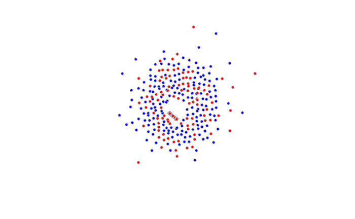

```r
V(polblogs)$color = c('blue','red')[(V(polblogs)$LeftRight + 1)]
plot(polblogs,
     vertex.label = NA,
     vertex.size = 4,
     vertex.frame.color = 'gray',
     edge.arrow.size = 0.1,
     edge.width = .1,
     margin = 0)
```

It looks like too many blogs have no connection at all. For our purpose, they contain no information. So we need to locate them and delete them from our analysis:

```r
# get adjacency matrix
matrix.polblogs = get.adjacency(polblogs,sparse=F)
# remove self-citation
diag(matrix.polblogs) = 0
LeftRight = V(polblogs)$LeftRight
# delete those with no incoming or outgoing relations
matrix.polblogs.small = matrix.polblogs
LeftRight.small = LeftRight
threshold = 1
while(any(apply(matrix.polblogs.small,1,"sum") < threshold) || any(apply(matrix.polblogs.small,2,"sum") < threshold)){
  inf.Index = (apply(matrix.polblogs.small,1,"sum") < threshold) | (apply(matrix.polblogs.small,2,"sum") < threshold)
  matrix.polblogs.small = matrix.polblogs.small[!inf.Index,!inf.Index]
  LeftRight.small = LeftRight.small[!inf.Index]
}
```

After deleting them, we create a sub-network, which is as follows:

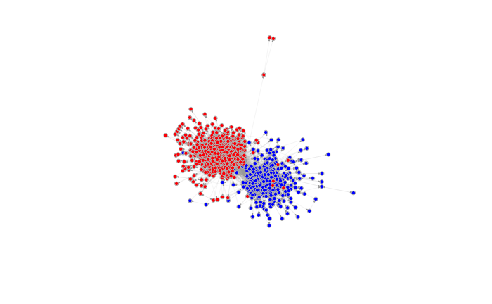

```r
polblogs.small = graph.adjacency(matrix.polblogs.small)
V(polblogs.small)$LeftRight = LeftRight.small
V(polblogs.small)$color = c('blue','red')[(V(polblogs.small)$LeftRight + 1)]
plot(polblogs.small,
     vertex.label = NA,
     vertex.size = 4,
     vertex.frame.color = 'gray',
     edge.arrow.size = 0.1,
     edge.width = .1,
     margin = 0)
```

It looks nice and reasonable. One can see online political blogs are indeed divisive. Each camp cites mostly among themselves. There are a few outliers, especially in conservatives. But we do not have a solid foundation for them to be the “wrong” data points. Also, remember some of these red/blue labels are automatically categorized or manually labeled by Adamic and Glance (2005). They are not necessarily 100% reliable. So I choose to keep the “outliers.”

## Estimation

Now we can proceed to estimation.

```r
library(compiler)
enableJIT(3) # enable the just-in-time compliation
library(maxLik)
LogitNetworkIdealPointS.Two = function(Y, Tol = 1e-4){
  # Two step MLE
  # Y: sociomatrix
  llik.cost = function(b, Y, theta0, n){
    # n = nrow(Y)
    # cost = b
    costM = matrix(b,n,n)
    # c(0,theta0) # ideal points
    thetaM = matrix(c(0,theta0),n,n)
    utility = -(thetaM - t(thetaM))^2 - costM
    ll = - Y * log(1+exp(-utility)) - (1-Y) * log(1+exp(utility))
    diag(ll) = NA
    return(na.omit(c(t(ll))))
  }
  grad.cost = function(b,Y, theta0, n){
    costM = matrix(b,n,n)
    # c(0,theta0) # ideal points
    thetaM = matrix(c(0,theta0),n,n)
    utility = -(thetaM - t(thetaM))^2 - costM
    dC = -Y * exp(-utility) / (1+exp(-utility)) + (1-Y) * exp(utility) / (1+exp(utility))
    diag(dC) = 0
    return(apply(dC,1,"sum"))
  }
  llik.theta = function(b,Y,cost,n){
    # n = nrow(Y)
    # c(0,b) # ideal points
    thetaM = matrix(c(0,b),n,n)
    costM = matrix(cost,n,n)
    utility = -(thetaM - t(thetaM))^2 - costM
    ll = - Y * log(1+exp(-utility)) - (1-Y) * log(1+exp(utility))
    diag(ll) = NA
    return(na.omit(c(t(ll))))
  }
  grad.theta = function(b,Y,cost,n){
    # n = nrow(Y)
    # c(0,b) # ideal points
    thetaM = matrix(c(0,b),n,n)
    costM = matrix(cost,n,n)
    utility = -(thetaM - t(thetaM))^2 - costM
    dtheta = -Y * 2 * exp(-utility) * (thetaM - t(thetaM)) / (1+exp(-utility)) +
      (1-Y) * 2 * exp(utility) * (thetaM - t(thetaM)) / (1+exp(utility))
    diag(dtheta) = 0
    return((apply(dtheta,1,"sum") + apply(-dtheta,2,"sum"))[-1])
  }
  n = nrow(Y)
  StartValue.cost = runif(n)
  # the first individual's ideal point is normalized to 0
  StartValue.theta = runif(n-1)
  costGood = F # indicator for the cost loop
  thetaGood = F # indicator for the theta loop
  thetall = 100 # initial likelihood
  costll = 100 # initial likelihood
  loop = 1 # loop count
  while((costGood == F) || (thetaGood == F)){
    # cost loop
    costMax = maxLik(llik.cost, grad = grad.cost,
                     start = StartValue.cost, method="BFGS",
                     iterlim = 500, tol = Tol, finalHessian = F,
                     Y = Y, theta0 = StartValue.theta, n = n)
    if(abs(costMax$maximum - costll) < Tol){
      costGood = T
    }else{
      costGood = F
    }
    costll = costMax$maximum
    StartValue.cost = costMax$estimate
    cat("Cost estimation is done at loop",loop, "\n")

    # theta loop
    thetaMax = maxLik(llik.theta, grad = grad.theta,
                      start=StartValue.theta, method="BFGS",
                      iterlim = 500, tol = Tol, finalHessian = F,
                      Y = Y, cost = StartValue.cost, n = n)
    if(abs(thetaMax$maximum - thetall) < Tol){
      thetaGood = T
    }else{
      thetaGood = F
    }
    thetall = thetaMax$maximum
    StartValue.theta = thetaMax$estimate
    cat("Theta estimation is done at loop", loop, "\n")

    cat("loop =", loop, "is done!\n\n")
    loop = loop + 1
  }
  ## One step at the end to get Hessian
  print("Finalizing...\n")
  costMax = maxLik(llik.cost, grad = grad.cost,
                   start = StartValue.cost, method="BFGS",
                   iterlim = 500,
                   Y = Y, theta0 = StartValue.theta, n = n)
  thetaMax = maxLik(llik.theta, grad = grad.theta,
                    start=StartValue.theta, method="BFGS",
                    iterlim = 500,
                    Y = Y, cost = StartValue.cost, n = n)
  return(list(thetaMax,costMax))
}
```

The estimation takes a couple of minutes to run on a regular ultrabook (e.g., I use a MacBook Pro 13in 2017 base model).

```r
blog.result = LogitNetworkIdealPointS.Two(Y = matrix.polblogs.small)
```

As stated above, I use a two-step approach to maximize the likelihood function. The first step is estimating $C_i$’s (in the code above $C_i$ is called “cost” under the understanding that $C_i$ represents the “net cost” of establishing a relation) for a given set of $\theta_i$’s. The likelihood function at this stage is coded in the function `llik.cost()`. After the cost loop is done, I move on to estimate $\theta_i$’s by providing the previously estimated $C_i$’s. The likelihood function at this step is called `llik.theta()`. These two steps move on alternately until both have converged.

To speed up the calculation, I also provide analytical gradients. They are `grad.cost()` and `grad.theta()`. Note that analytical Hessian is not necessary as common quasi-Newton methods (e.g., the Broyden–Fletcher–Goldfarb–Shanno (BFGS) algorithm used here) do not compute Hessian.

## Calibration

After the estimation, we need to calibrate the results as the $\theta_i$’s are in invariant to horizontal shifts. To do so, I utilize the pre-determined labels coming with the data and pick the mean of the liberal and conservative medians as the new zero point. I also find the algorithm puts conservatives on the left side while liberals on the right. So I flip them to map to our understanding. The code for calibration is as follows:

```r
Calibrate = function(input,label){
  m.R = median(input[as.logical(label)])
  m.D = median(input[!as.logical(label)])
  midPoint = (m.R + m.D)/2
  output = input - midPoint
  if(m.R < midPoint && m.D > midPoint){
    output = -output
  }
  return(output)
}
idealPoints = Calibrate(c(0,blog.result[[1]]$estimate), LeftRight.small)
```

## Results

The ideal points can be plotted as follows:

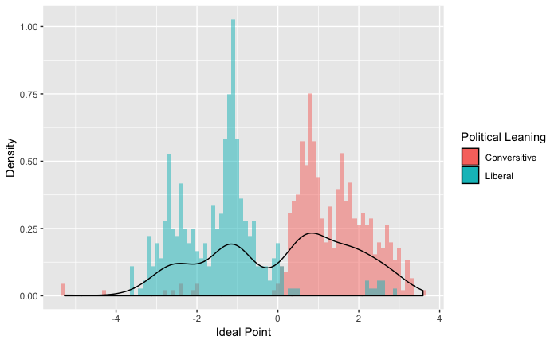

```r
library(ggplot2)
ggplot(data.frame(idealPoints, LeftRight.small)) +
  geom_histogram(aes(x=idealPoints, fill = factor(1 - LeftRight.small),
                     y = ..density..),
                 binwidth=.1,alpha=.5, position="identity") +
  geom_density(aes(x=idealPoints)) +
  xlab("Ideal Point") +
  ylab("Density") +
  scale_fill_discrete(name = "Political Leaning",
                      breaks=c("0", "1"),
                      labels=c("Conversitive", "Liberal"))
```

The figure is colored with the labels in the dataset. As one can see, the algorithm correctly assigns negative ideal points to liberal-leaning blogs and positive ideal positions to conservative blogs. As expected, there are some “outliers” on both sides since these “outliers” cite the other side too much. Also, there appear to be two groups in both camps: a more moderate group and a more extreme one. This is especially the case for liberal blogs. A third major finding is that the moderate group, a group of blogs that cite both sides equally, does not appear. It is possible that moderates do not bother to run political blogs or the population is indeed divided politically.

# Discussion

## Is this approach any useful?

If we treat this approach simply as a classifier, then it performs well. Assuming the labels coming with the dataset are 100% correct, then this approach predicts 96% of the data points correctly.

```r
Score = function(input, label){
  correct = (input>=0) == as.logical(label)
  return(sum(correct)/length(correct))
}
Score(idealPoints, LeftRight.small)
```

```
[1] 0.9594096
```

However, this approach can reveal more information than a simple classifier. It will tell not only *if* people are liberal/conservative, but *how* liberal/conservative they are. As well-known, political views are associated with many characteristics and preferences of people. Knowing people’s political views can help with targeted political advertising, marketing, etc.

Compared to text-based analysis, which requires individuals in the network to post political relevant contents, this approach requires only network structures to work. It means as long as people take political views into consideration when they form relations in a network, this approach can tell us their political views. For example, I never post my political views on my twitter, but I expect this approach to reveal my political preference.

## Can this approach be generalized to other areas?

Yes. It essentially reveals people’s preference based on their choices in a social network. For other social networks with taste-like preferences (imagine a restaurant network where people can follow chefs), this approach also likely can be applied.